# ch2: Data + Sampling Distributions

Steve Newns

May 10, 2018

## Data + Sampling Distributions

Proliferation of data of varying quality + relevance reinforces need for **sampling** as a tool to work efficiently w/ a variety of data + to **minimize bias**. Even w/ big data projects, predictive models = typically developed + piloted w/ samples + they’re used in tests of various sorts (e.g., pricing, web treatments)

**Population** = *unknown* distribution, only thing available = sample of said population + the *sample’s* empirical* distribution retrived via a sampling procedure

- traditional stats = population parametes that **require strong assumptions**, modern stats = sample statistics where **such assumptions are not needed**

DS should focus on sampling procedures + data *actually at hand*, sometimes from **a physical process that can be modeled** (flipping coins = binomial distribution)

- ANY real-life binomial can be modeled effectively via a coin flip w/ *modified specified success probabilities*

Can then gain additional insights via understanding the population.

### Random sampling + sample bias

Population (`N`) = large, defined but sometimes *theoretical or imaginary* set of data, and sample (`n`) = its subset

- **Random sampling** = drawing elements into a sample at random where each available member = equal chance of being drawn in each draw (results in simple random sample), *with or without replacement*
- **Stratified sampling** = dividing population into **strata** + randomly sampling from each strata.
- **Simple random sample** = random sampling *without stratifying the population*
- **Sample bias** = misrepresents the population.
- **SELF-SELECTION SAMPLING BIAS** = reviews of restaurants, hotels, cafes, etc. on social media = prone to bias b/c people submitting them = NOT randomly selected + have taken initiative to write = leads to self-selection bias
- people motivated to write reviews may be those w/ poor experiences, have an association w/ establishment, or simply be a different type of person from those who do NOT write reviews.
- While self-selection samples can be unreliable indicators of true state of affairs, they *may be more reliable in simply comparing 1 establishment to a similar one b/c the same self-selection bias might apply to each*

Data *quality* often matters more than *quantity* when making estimates/models based on sample = involves **completeness, consistency of format, cleanliness, + accuracy of individual DPs**, + statistics adds notion of **representativeness**

- Classic example = Literary Digest (1936) polled subscriber base = 10M+, Gallup poll = 2k w/ difference in selection of those polled.
- LD = little attention to method of selection = polled relatively high socioeconomic status (own subscribers = owned luxuries like phones + automobiles, so appeared in marketers’ lists) = sample bias
- **sample was different in some *meaningful nonrandom way* from the larger population it was meant to represent**
- **nonrandom* = important b/c** hardly any sample will be *exactly* representative of a population** but sample *bias* occurs when difference = meaningful + can be expected to continue for other samples drawn in the same way as the 1st

#### Bias

*Statistical* **bias** = measurement/sampling errors that are **systematic** + produced by measurement/sampling process

- Important distinction is made between errors due to *random chance* vs. due to bias.
- Ex: Consider physical process of a gun shooting @ a target = will not hit absolute center of the target every time, or even much at all.
- **Unbiased process** = produces error, but it’s *random* + does not tend strongly in any direction

Bias comes in *different forms* = may be *observable or invisible*

If result *suggests* bias (by reference to **benchmark** or **actual values**) = often an indicator that statistical/ML model has been misspecified or an important predictor was let out

#### Random selection

To avoid sample bias, use more scientifically-chosen methods to get more representative samples, heart of which lies in random sampling = not always easy as *proper definitions of populations are key but are difficult*

- generate a representative profile of customers via a pilot survey that survey needs to be representative but is labor intensive.
- 1. *Define* WHO a customer is = might select all customer records where purchase amount > 0. Include all past customers, or refunds? Internal test purchases? Resellers? Both billing agent + customer?
- 2. Must specify a sampling *procedure* = “select 100 customers @ random,” or where a sampling from a **flow** (e.g., real-time transactions or web visitors), *timing considerations may be important* (10 AM weekday visitor may be different from 10 PM weekend)
- **Stratified sampling** = population divided into **strata** + random samples are taken from each stratum.
- Political pollsters might seek to learn electoral preferences of whites, blacks, + Hispanics = SRS would yield too few blacks + Hispanics, so those strata could be **overweighted** in stratified sampling to yield equivalent sample sizes.

#### Size v. Quality

In era of big data = sometimes surprising if *smaller is better* + *time + effort* spent on random sampling not only will reduce bias, but also allow greater attention to EDA + data quality

- Ex: Missing data + outliers may contain useful info + it might be too expensive to track down + evaluate these w/in millions of records, but doing so in a sample of several thousand records may be feasible.
- Data plotting + manual inspection bog down w/too much data.

*So when are massive amounts of data needed?*: Classic scenario = when data is not only big, but **sparse** as well

- Google search queries: columns = terms, rows = individual queries, cell = 0/1 if query contains term w/ goal = ddetermine best predicted search destination for a given query.
- 150K+ words in English language + Google processes > 1 trillion queries/year = yields a huge matrix + vast majority of entries = 0
- This = true big data problem: *only when enormous quantities of data are accumulated can effective search results be returned for most queries + more data accumulates = better the results*
- Not problem for popular search terms = effective data found fairly quickly for handful of extremely popular topics trending @ particular time
- Real value of modern search tech = ability to return detailed + useful results for a huge *variety* of search queries, including those that occur only w/ v. small a frequency,

# of actual pertinent records (exact search query, or something very similar, appears, together w/ info on what link people ultimately clicked on) might need only be in the thousands to be effective.

- However, many trillions of DPs = needed to obtain these pertinent records (random sampling will not help).

#### Sample Mean versus Population Mean

Mean of a sample from a population = $\bar{x}$ whereas ${\mu}$ = mean of a population.

**Info about samples = *observed*, + info about large populations = often *inferred* from smaller samples** = keep the 2 things separate in symbology

### Selection Bias

**Selection bias** = practice of selectively choosing data — consciously or unconsciously — in a way that leads to a conclusion that is misleading or ephemeral.

**Bias** = systematic error **Data snooping** = extensive hunting through data in search of something interesting. **Vast search effect** = Bias or nonreproducibility resulting from repeated data modeling, or modeling data w/ large #’s of predictor variables, $p$

If you specify a hypothesis + conduct well-designed experiment to test it = can have high confidence in conclusion

Often, one looks @ available data + tries to discern patterns, *but is pattern = real, or just a product of data snooping?* (“If you torture the data long enough, sooner or later it will confess”)

Difference between a phenomenon verified when testing a hypothesis via experiment vs. a phenomenon discovered by perusing available data can be illuminated w/ thought experiment.

- Someone can flip a coin on H on next 10 tosses, you challenge her (equivalent of an experiment) + she proceeds to toss 10 H
- Clearly you ascribe some special talent to her b/c $p(10 H straight by chance)$ = 1/1000
- Do this w/ 20k people = chance *someone* gets 10 H = extremely high (> 99%, or (1-$p$(no 10 H)$)
- Clearly, selecting, **after the fact**, the person(s) who gets 10 H does not indicate any special talent = most likely luck.

Since **repeated review of large data sets = a key value proposition in DS, selection bias is something to worry about**

Form of selection bias particular concern to DS = **vast search effect** = repeatedly run different models + ask different questions w/ large data set = bound to find something interesting but is the result truly something interesting, or is it the chance outlier?

Can guard against w/ **holdout set(s)** against which to validate performance, + use of **target shuffling = a permutation test, in essence, to test the validity of predictive associations that a data mining model suggests**

*Other typical forms of selection bias in statistics*: Nonrandom sampling (see sampling bias), cherry-picking data, selection of time intervals that accentuate a partiular statistical effect, stopping an experiment when the results look “interesting.”

#### Regression to the Mean

**Regression to the mean** = phenomenon involving successive measurements on a given variable: extreme observations tend to be followed by more central ones, so attaching special focus + meaning to extreme value can lead to a form of selection bias.

Sports = “rookie of the year, sophomore slump” phenomenon = Among athletes who begin career in a given season (rookie class), 1 always performs better generally does not do as well in his 2nd year. Why not?

In nearly all major sports, at least those played w/ a ball or puck, 2 elements play a role in overall performance: Skill + Luck

Regression to the mean = consequence of a particular form of selection bias = select rookie w/ best performance, then skill + good luck = probably contributing., + in next season, skill will still be there but, in most cases, luck will not, so performance regresses

Phenomenon was 1st IDed by Francis Galton in 1886 in connection w/ genetic tendencies (children of extremely tall men tend not to be as tall as their father)

*WARNING*: Regression to the mean = *distinct* from linear regression statistical modeling method = linear relationship is estimated between predictors + outcome

*KEY IDEAS* Specifying a hypothesis + *collecting data following randomization + random sampling principles* ensures against bias

- All other forms of data analysis run risk of bias resulting from data collection/analysis process (repeated running of models in data mining, data snooping in research, after-the-fact selection of interesting events)

### Sampling Distribution of a Statistic

**Sampling distribution** = distribution of some sample statistic *over many samples drawn from same population* + much of classical statistics = concerned w/ *making* inferences from (small) samples to (very large) populations*.

- **Sample statistic** = metric calculated for a sample of data drawn from a larger population.
- **Data distribution** = frequency distribution of individual values in a data set.
- **Sampling distribution** = frequency distribution of a sample statistic over many samples or resamples.
- **CLT** = Tendency of sampling distribution to take on a normal shape as sample size rises.
- **Standard error** = variability (StdDev) of a sample statistic over many samples (*NOT* SD = variability of *individual data values*)

Typically samples = drawn w/ goal of measuring something (w/ a *sample statistic*) or modeling something (w/ a statistical or ML model).

**Since estimate/model is based on a sample, it might be in error = different in a different sample** = therefore interested in how different it might be w/ a key concern= **sampling variability**

W/ lots of data, could draw additional samples + observe distribution of a sample stat directly

*Typically, will calculate estimate/model using as much data as is easily available, so option of drawing additional samples from population is not readily available*

*WARNING*: Important to distinguish between distribution of the individual DPs (data distribution) + distribution of a sample statistic (sampling distribution)

Distribution of a sample statistic = likely to be more regular + bell-shaped than distribution of data itself + larger a sample statistic is based on = more this is true + larger the sample, narrower the distribution of the sample statistic.

Ex: Annual income for loan applicants to Lending Club w/ 3 samples of data: a sample of k values, a sample of 1k means of 5 values, + a sample of 1k means of 20 values w/ histogram of each sample:

```r
library(tidyverse)
library(ggplot2)

loans <- read.csv('../../../../PracticalStatsForDataScientists_50/data/loans_income.csv')
```

```r
smpl <- data.frame(income=sample(loans$x,1000),type="data_dist")
smplMean_5 <- data.frame(income=tapply(sample(loans$x,1000*5),rep(1:1000, rep(5,1000)), FUN = mean),type="mean_of_5")
smplMean_20 <- data.frame(income=tapply(sample(loans$x,1000*20),rep(1:1000, rep(20,1000)), FUN = mean),type="mean_of_20")

income <- rbind(smpl,smplMean_5,smplMean_20) %>%
  mutate(type = factor(type,levels=c("data_dist","mean_of_5","mean_of_20"),labels=c('Data','Mean of 5','Mean of 20')))
```

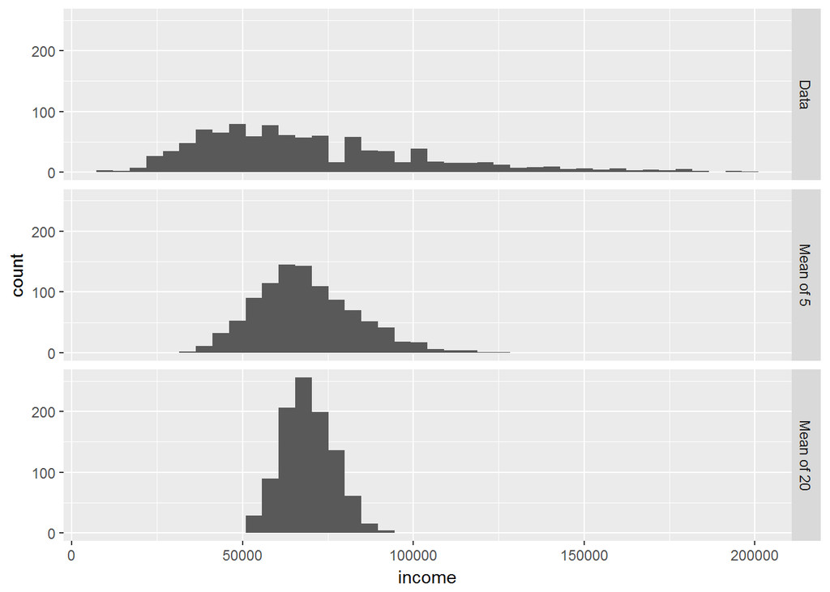

```r
income %>%
  ggplot(aes(x=income)) +
  geom_histogram(bins=40) +
  facet_grid(type ~ .)
```

#### CLT

CLT says that means drawn from multiple samples will resemble bell-shaped normal curve even if source population is not normally distributed, provided sample size $n$ = large enough + departure of the data from normality = not too great

CLT allows normal-approximation formulas like **t-distribution** to be used in calculating sampling distributions for inference (**CI’s + hypothesis tests**).

CLT = lot of attention in traditional stats texts b/c it underlies machinery of hypothesis tests + CI’s so DS’s should be aware of this role, but, since formal hypothesis tests + CI’s play a small role in DS, + the **bootstrap** = available in *ANY* case, CLT is not so central in DS

#### Standard Error

Std Error = single metric that sums up variability in sampling distribution for a statistic + can be estimated using a statistic based on the SD $s$ or $\sigma$ of the sample values, + the sample size $n$: $SE = \frac {s} {\sqrt{n}}$

**As $n$ increases, SE decreases** = *square-root of n rule*: in order to reduce SE by a factor of 2, $n$ must be increased by a factor of 4.

Validity of SE formula arises from the CLT (don’t *need* to rely on CLT to understand SE)

- 1. Collect a # of brand new samples from population.
- 2. For each new sample, calculate the statistic
- 3. Calculate SD of the statistics computed in step 2 + use it as estimate of SE

In practice, approach of collecting new samples to estimate SE = typically not feasible (+ statistically very wasteful). Fortunately, it turns out it is not necessary to draw brand new samples + can use **bootstrap resamples** = modern statistics standard way to estimate SE + can be used for virtually any stat + does not rely on CLT or other distributional assumptions.

**REMEMBER**: SD = measures variability of individual DPs + SE = measures variability of a sample metric

### Bootstrap

Bootstrap = easy + effective way to estimate sampling distribution of a stat or of model parameters via drawing additional samples, *w/ replacement* from the sample itself + recalculate the statistic/model for each resample

- **does not necessarily involve any assumptions about the data or the sample stat *being normally distributed***

**Bootstrap sample** = taken w/ replacement from an *observed* data set. **Resampling** = process of taking repeated samples from *observed* data –> includes both bootstrap + permutation (shuffling) procedures

imagine bootstrap as replicating original sample thousands/millions of times to get hypothetical population that embodies all knowledge from original sample + is just larger + then can draw samples from this hypothetical population w/ purpose of estimatinga sampling distribution

In practice = not necessary to *actually* replicate sample huge # of time + can simply replace each observation after each draw to effectively create an infinite population in which probability of an element being drawn remains unchanged from draw to draw

Algorithm for a bootstrap resampling of the mean from sample of size $n$:

- 1. Draw a sample value, record it, replace it.
- 2. Repeat $n$ times.
- 3. Record mean of the $n$ resampled values.
- 4. Repeat steps 1–3 $R$ times.
- 5. Use the $R$ results to:
- 1. Calculate their SD (estimates sample mean SE).
- 2. Produce a histogram or boxplot.
- 3. Find a CI.

$R$ = # of iterations of the bootstrap = set somewhat arbitrarily: more iterations = more accurate SE estimate or CI estimate

Result = set of sample stats/estimated model parameters which can be examined to see how variable they are.

`boot` package combines these steps in 1 function

```r
library(boot)

stat_fun <- function(x,idx) {
  # Compute median for given sample specified by index = idx
  median(x[idx])
}
(boot_obj <- boot(loans$x, R = 1000, statistic=stat_fun))
```

```
##
## ORDINARY NONPARAMETRIC BOOTSTRAP
##
##
## Call:
## boot(data = loans$x, statistic = stat_fun, R = 1000)
##
##
## Bootstrap Statistics :
##     original   bias    std. error
## t1*    62000 -61.6735    189.9929
```

Bootstrap can be used w/ multivariate data, where rows = sampled as units + a model might then be run on the bootstrapped data, for example, to estimate **stability**/variability of model parameters, or to improve predictive power.

**Bootstrap aggregating** (**bagging**) = W/ classification + regression trees (**CART** or **decision trees**), running multiple trees on bootstrap samples + then averaging their predictions (or, w/ classification, taking a majority vote) generally performs better than using a single tree

Repeated resampling of the bootstrap = conceptually simple (Julian Simon, an economist + demographer, published a compendium of resampling examples, including the bootstrap, in 1969 text *Basic Research Methods in Social Science (Random House)*) but also computationally intensive + was not a feasible before widespread availability of CPU power.

Technique gained its name + took off w/ publication of several journal articles + a book by Stanford statistician Bradley Efron in late 1970s + early 1980s, + was particularly popular among researchers who use stats but are not statisticians + for use w/ metrics or models where mathematical approximations = not readily available.

**Sampling distribution of the mean = well established since 1908 but sampling distribution of many other metrics has not** Bootstrap can be used for sample size determination + we experiment w/ different values for $n$ to see how the sampling distribution is affected

*WARNING*: Bootstrap does *NOT* compensate for small sample size + does not create new data, nor does it fill in holes in an existing data set = merely informs us about how lots of additional samples would behave when drawn from a population like our original sample.

#### Resampling versus Bootstrapping

Sometimes “resampling” = used synonymously w/ “bootstrapping”, but more often, **resampling** also includes **permutation procedures** where multiple samples are combined + sampling may be done w/out replacement. I

*KEY IDEAS*: Bootstrap = powerful tool for assessing variability of a sample stat + can be applied in similar fashion in a wide variety of circumstances, w/out extensive study of mathematical approximations to sampling distributions + also allows us to estimate sampling distributions for stats where no mathematical approximation has been developed.

- When applied to predictive models, aggregating multiple bootstrap sample predictions (bagging) can outperform use of a single model.

### CI’s

- Freq. tables, histograms, boxplots, +stdErr’s = all ways to understand *potential* error in a sample estimate + so are **CI’s** = the % of CI’s, constructed in *SAME WAY* from *SAME POPULATION* that’re expected to contain statistic of interest.

Natural human aversion to uncertainty; many, while acknowledging uncertainty, nonetheless place undue faith in estimates when presented as a single # (**point estimate**) + presenting estimates as a *range* = 1 way to counteract this tendency.

CI’s do this in a manner grounded in statistical sampling principles. CI’s always come with a **coverage level**, expressed as a (high) % = 90% or 95%. 1 way to think of a **90% CI: interval that encloses the central 90% of the bootstrap sampling distribution of a sample statistic** or, more generally, **an x% CI around a sample estimate should, on average, contain similar sample estimates x% of the time *when a similar sampling procedure is followed***

Given sample of size $n$ + a sample stat of interest, the algorithm for a **bootstrap CI** is as follows: * 1. Draw random sample of size $n$ *with replacement* from the data (a **resample**) * 2. Record the stat of interest for the resample. * 3. Repeat steps 1–2 many ($R$) times. * 4. For an x% CI, trim `[(1 – [x/100]) / 2]`% of the $R$ resample results from either end of the distribution. * 5. Trimmed points = the endpoints of an x% bootstrap CI

Bootstrap = general tool that can be used to generate CIs for most stats or model parameters. Stat textbooks + software, w/ roots in over a half-century of CPU-less statistical analysis, will also reference CIs generated by formulas, especially the t-distribution

*NOTE*: Of course, we are *really* interested in for a sample result = *“what is the probability the *true* value lies w/in a certain interval?”*, but this is not really the question a CI answers, but it ends up being how most people interpret the answer.

The probability question associated w/ a CI starts out w/ phrase **“Given a sampling procedure + a population, what is the probability that…”** To go in the opposite direction, **“Given a sample result, what is the probability that (something is true about the population),”** involves more complex calculations + deeper imponderables.

The % associated w/ a CI = **level of confidence** + higher level of confidence = wider interval, + also smaller sample = wider interval (i.e. more uncertainty). Both make sense: the more confident you want to be, + the less data you have, the wider you must make a CI to be sufficiently assured of capturing the true value.

*NOTE*: For a DS, a CI= a tool to get an idea of how variable a sample result might be. **DSs would use this info** not to publish a scholarly paper or submit a result to a regulatory agency (as a researcher might), but **most likely to communicate the potential error in an estimate, +, perhaps, learn whether a larger sample is needed.**

***KEY IDEAS**: CIs = typical way to present estimates as an interval range, + the more data you have, the less variable a sample estimate will be.

- The lower the level of confidence you can tolerate = the narrower the CI will be.
- Bootstrap = effective way to construct confidence intervals.
- Botstrap approach to CIs = see **Introductory Statistics and Analytics: A Resampling Perspective by Peter Bruce (Wiley, 2014)** or **Statistics by Robin Lock** and four other Lock family members (Wiley, 2012).
- Engineers, who have a need to understand precision of measurements, use CIs perhaps more than most disciplines, + **Modern Engineering Statistics by Tom Ryan (Wiley, 2007)** discusses CIs
- It also reviews a tool that is just as useful + gets less attention: **prediction intervals** around a single value, as opposed to a mean or other summary statistic. a mean or other summary statistic

### Normal Distribution

Gaussian/Bell-shaped normal = iconic in traditional stats

- iconic but perhaps overrated: George W. Cobb (statistician noted for contribution to philosophy of teaching intro stats, argued in a November 2015 editorial in the *American Statistician* that the “standard intro course, which puts the normal at its center, had outlived the usefulness of its centrality”
- common misconception = called “normal” b/c most data follows its distribution
- Most vars used in typical SD project (+ most raw data as a whole) = *NOT* normally distributed:
- Utility of the Gaussian derives from the fact that many *stats* = normally distributed *in their sampling distribution.*
- **Even so, assumptions of normality = generally a last resort, used when empirical probability distributions, or bootstrap distributions, are not available**

Gaussian = Carl Friedrich Gauss, German mathematician from late 18th + early 19th century.

- Another name = the “error” distribution.
- Statistically speaking, **error** =the difference between an actual value + a statistical estimate (SD = based on errors from the mean of the data)

The fact that distributions of sample stats are often Gaussian has made it a powerful tool in the development of mathematical formulas that approximate those distributions

- essential to historical development of stats b/c it permitted mathematical approximation of uncertainty + variability
- raw data = typically not normal, errors often are, as are averages + totals in large samples.

68% of data in Gaussian distribution = w/in 1 SD, 95% w/in 2 SD, 99.7% w/in 3 SD

#### Standard Normal + QQ Plots

**Standard normal** = units on the x are expressed in terms of SDs from mean.

- To compare data to a standard normal distribution, **normalization/standardization** = subtract mean from DPs + then divide by SD = **a z-score** (normal = sometimes called the z-distribution)
- **QQ-Plot** = visually determine how close a sample is to Gaussian = orders z-scores from low to high + plots each value’s z-score on the y-axis
- x-axis = corresponding quantile of a Gaussian distritbution *for that value’s rank* = **theoretical quantile**
- Since the data = normalized, units correspond to # of SDs away from mean
- If poitns = roughly diagonal line, sample distribution can be considered close to Gaussian

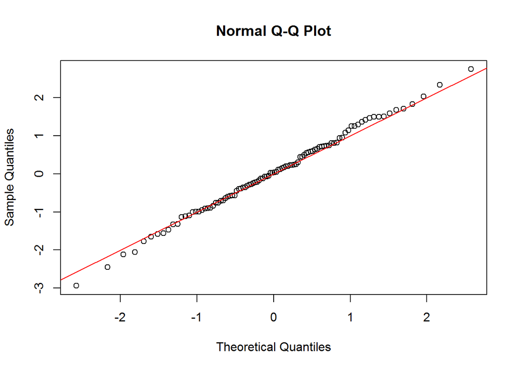

```r
s <- rnorm(100)
qqnorm(s)
abline(a=0,b=1,col='red')
```

*WARNING*: Converting data to z-scores (standardizing/normalizing data) does *NOT* make data normally distributed = just puts data on same scale as standard normal distribution, often for comparison purposes.

### Long-tailed distributions

Data = generally not normally distributed.

**Tail** = long narrow portion of a frequency distribution, where **relatively extreme values occur at low frequency** **Skew** = 1 tail of distribution = longer than other.

Gaussian is often appropriate + useful w/ respect to distribution of errors + sample stats, typically does not characterize distribution of raw data = sometimes highly skewed/asymmetric (income data) or discrete (binomial data)  
Both symmetric + asymmetric distributions may have **long tails** = the extreme values (small + large).  
Long tails + guarding against them = widely recognized in practical work.

- Nassim Taleb = **the black swan theory** = predicts anamolous events, such as stock market crash = much more likely to occur than would be predicted by the Gaussian

Good example = stock returns.

```r
stocks <- read.csv('../../../../PracticalStatsForDataScientists_50/data/sp500_px.csv')
```

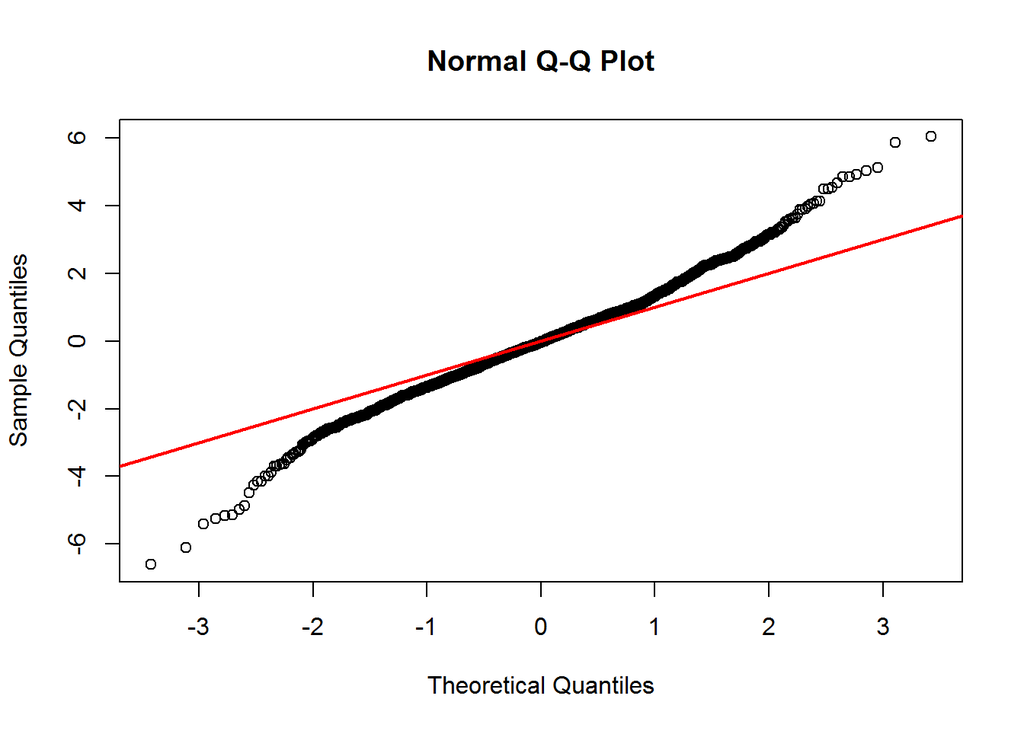

```r
nflx <- stocks %>%
    select(NFLX)
nflx <- diff(log(nflx[nflx>0]))
qqnorm(nflx)
abline(a=0,b=1,col='red',lwd=2)
```

QQ-Plot for daily stock returns for Netflix = pts = far below line for low values + far above for high values = means much more likely to observe extreme values than would be expected if data were Gaussian Figure, also, points = close to the line for data w/in 1 SD = Tukey refers to this phenomenon as data being “normal in the middle,” but having much longer tails

*NOTE*: Much statistical lit. about task of fitting statistical distributions to observed data, beware an excessively data-centric approach to this job, which is as much art as science.

- Data = variable, + often consistent, on its face, w/ more > 1 shape + type of distribution
- **typical that domain + statistical knowledge must be brought to bear to determine what type of distribution is appropriate to model a given situation**
- might have data on level of internet traffic on a server over many consecutive 5-sec periods = useful to know best distribution to model “events per time period” = **Poisson**

*KEY IDEAS*: Most data = not Gaussian + assuming Gaussian can lead to underestimation of extreme events (“black swans”)

### Student’s/Gossett’s t distribution

t distribution = used extensively in depicting distributions of sample statistics (typically sample means) = normally-shaped but w/ thicker + longer tails

- families = different t-distributions depending on how large sample is: larger = more normal
- widely used as reference basis for distribution of sample means, differerences between 2 sample means, regression parameters, + more

Gossett: “What is the sampling distribution of the mean of a sample drawn from a larger population?” = started w/ resampling experiment of n=4 from a data set of 3k measurements of criminals’ height + left-middle-finger lengths + plotted standardized results (z-scores) on x + frequency on y

Separately derived a function, = **Student’s t** + fit it over the sample results, plotting the comparison

# of different statistics can be compared, after standardization, to the t-distribution, to estimate CIs in light of sampling variation.

Lacking CPUs, statisticians turned to math + functions such as t-distribution to approximate sampling distributions (CPU power in 80s enabled practical resampling experiments, but by then, use of the t-distribution + similar distributions had become deeply embedded in stats)

t-distribution’s accuracy in depicting behavior of a sample stat **requires the distribution of that statistic for that sample be shaped like a normal distribution**: turns out sample stats = often normally distributed, even when underlying population data is NOT (fact led to widespread application of t-distribution) = CLT

*NOTE* DS don’t need to know whole lot about t-distribution + CLT = used in classical statistical inference, not as central to purposes of DS

- **Understanding + quantifying uncertainty + variation = important to DS**, but **empirical bootstrap sampling** can answer most questions about sampling error.
- However, DS routinely encounter t-statistics in output from software (A-B tests, regressions, etc.) = so familiarity is helpful

### Binomial distribution

- **Trial** = event w/ a *discrete* outcome
- **Success** = outcome of interest for a trial.
- **Binomial trial/Bernoulli trial** = trial w/ 2 outcomes
- **Binomial/Bernoulli distribution** = Distribution of # of successes in $x$ trials.

binomial outcomes lie @ heart of analytics since they’re often a culmination of a decision or other process (buy/don’t buy, click/don’t click, survive/die, etc.)

Central to understanding binomial distribution = idea of a set of trials, each w/ 2 possible outcomes w/ *definite probabilities* (need not be 50/50, just must sum to 1) where 1 = a “success” or a “rare” outcome

- success does not imply desirable or beneficial outcome, but indicates the outcome of interest (loan defaults or fraudulent transactions = relatively uncommon events we may be interested in predicting, but are not “good”)

**Binomial distribution** = *frequency distribution* of # of successes ($x$) in given # of trials ($n$) w/ specified success probability ($p$) in each trial.

- families = different t-distributions depending on values of $x$, $n$, and $p$.

Binomial distribution answers question like: *“If $p$ of a click converting to a sale = 0.02, what is the $p$ of observing 0 sales in 200 clicks?”*"

```r
# calculate binomial probabilities for 2 successes in 5 trials w/ p = .1
dbinom(x=2, size=5, p=0.1)
```

```
## [1] 0.0729
```

Often interested in determining $p$ of $x$ *or fewer* successes in $n$ trials

```r
# prob of seeing x OR LESS in n trials w/ p
pbinom(2, 5, 0.1)
```

```
## [1] 0.99144
```

`0.9914 = 99%` probability of observing 2 or fewer successes in 5 trials, where the probability of success for each trial = 10%

**Mean of a binomial distribution = $n*p$ = the expected # of successes in $n$ trials for success probability = $p$**, + variance = $n*p(1-p)$

W/ large enough # of trials (particularly when $p$ = close to .5), binomial = virtually indistinguishable from the normal

Calculating binomial probabilities w/ large $n$ = computationally demanding, + most statistical procedures use the normal w/ mean + variance, as an approximation

- W/ large $n$, + provided $p$ = not too close to 0 or 1, the binomial can be approximated by the normal

### Poisson and Related Distributions

Many processes produce events randomly @ a given overall rate (visitors at a site, cars @ a toll plaza (*events spread over time*), imperfections in a square meter of fabric, typos per 100 lines of code (*events spread over space*)

- **Lambda** = rate (per unit of time or space) at which events occur.
- **Poisson distribution** = frequency distribution of the *# of events* in sampled units of time or space.
- **Exponential distribution** = frequency distribution of *the time or distance* from 1 event to the next
- **Weibull distribution** = generalized version of the exponential, in which event rate is allowed to shift over time.

#### Poisson Distributions

From *prior* data we can estimate avg. # of events per unit of time/space, but might also want to know *how different this might be from 1 unit of time/space to another*

Poisson distribution tells us distribution of events per unit of time/space when sampling many such units = useful when addressing *queuing questions* like “How much capacity do we need to be 95% sure of fully processing the internet traffic that arrives on a server in any 5-second period?”

Key parameter in a Poisson distribution = **$\lambda$ = mean # of events that occurs in a specified interval of time/space*** + variance for a Poisson = *also* $\lambda$

Common technique = generate random #’s from a Poisson as part of a queuing simulation.

```r
# get 100 random #'s from a poission distribution w/ lambda = 2
rpois(100,lambda=2)
```

```
##   [1] 2 0 2 3 3 2 1 4 0 0 2 2 4 2 1 3 2 4 1 1 1 1 1 0 1 5 2 2 4 0 4 5 1 2 4
##  [36] 2 4 1 2 3 2 0 4 3 2 1 2 2 2 2 2 3 1 2 0 2 4 0 2 2 1 2 2 0 3 3 0 0 2 3
##  [71] 0 4 2 7 2 1 2 4 2 2 1 1 3 2 3 2 2 3 2 2 4 2 3 4 1 2 2 2 2 3
```

**This could represent, for example, if incoming customer service calls average 2/min., this simulate 100 minutes, returning the # of calls in each minute of those 100 minutes**

#### Exponential Distribution

Using same $\lambda$ parameter from Poisson distribution, can also model distribution of *time between events* (between visits to a site or cars arriving at a toll, as well as model time to failure or time required per service call)

```r
# get 100 numbers from 2 events per time period
rexp(100,rate=.2)
```

```
##   [1]  3.18722485  5.44423096  2.61934746  5.62926809  0.92866201
##   [6]  1.59967457  7.48277161  0.21209906  0.42150544  0.19451668
##  [11] 10.86569348  2.26857668  0.40644445  1.19746952  1.39494305
##  [16]  8.26859509  3.24971482  0.28167473 14.73530641  5.47284213
##  [21]  0.35602331  0.86017630  0.05492861 18.34019552  3.81636846
##  [26]  2.46185113  6.60022685  0.05174981  4.30771585  2.15979437
##  [31] 12.23590852  5.39584316  0.33721884  0.29825600 12.90527225
##  [36]  1.50442533  0.05482203  1.75422729  0.96892989  1.09813989
##  [41]  4.57706783  5.43986297  7.67930276  0.18446421  3.22422780
##  [46] 16.45233367 12.90696197 10.24023608  8.25468652  1.74723859
##  [51]  4.71883481  1.30437699  2.56480335  6.03241452  0.05669093
##  [56]  2.94026064  3.43715142  3.59654695  0.20161108  2.88383366
##  [61]  0.12171683 13.88729035  1.16889815  3.52158118 13.57354213
##  [66]  4.22145842 13.99373351  1.85808894 11.72390009 13.84485525
##  [71]  0.08590858  4.74598901  3.82557580  3.56660793  1.17356889
##  [76]  1.44363277  1.38389470  1.12537846  0.92396784  1.09977914
##  [81] 14.12678905 16.91006347  9.27028308  2.78583874  3.99286629
##  [86]  7.61520122  3.53128348  0.70811196  6.05851792  5.16811388
##  [91]  3.47407356  1.24000635  4.95345380  4.12441923  1.44084532
##  [96]  1.50293419  9.07026482  0.80947629  5.76389389  4.73268401
```

**Key assumption in any simulation study (for either the Poisson or exponential) = the rate, $\lambda$, remains *constant* over the period being considered**

- rarely reasonable in a global sense; traffic on roads/data networks varies by time of day + DOW
- But, time periods/areas of space *can usually be divided into segments sufficiently homogeneous so that analysis/simulation w/in those periods is valid*

#### Estimating the Failure Rate

Many applications = event rate $\lambda$ = known/can be estimated from prior data.

For *rare* events = not necessarily so

- Aircraft engine failure = sufficiently rare that, for given engine type, there may be little data on which to base an estimate of time between failures.

W/ no/little data = little basis on which to estimate an event rate

Can make some guesses: if no events have been seen after 20 hours = can be pretty sure rate is *not* 1/hour.

Via simulation or direct calculation of probabilities, can assess different hypothetical event rates + estimate threshold values below which the rate is very unlikely to fall.

If there is *some* data but not enough to provide a precise, reliable estimate of rate, a **goodness-of-fit test** can be applied to various rates to determine how well they fit the observed data.

#### Weibull Distribution

In many cases, event rate = not constant over time + if period over which it changes = much longer than typical interval between events, there is no problem; just subdivide the analysis into segments where rates = relatively constant,

If, however, *event rate changes over time of the interval*, exponential/Poisson distributions = no longer useful (likely to be case in mechanical failure where risk of failure increases as time goes by)